# Project Definition

Project Definition

The dataset "bodyPerformance.csv" has been obtained from a fitness research study conducted on a diverse group of individuals. Researchers collected various measurements, such as age, gender, weight, and fitness metrics, to analyze the relationships between these attributes. The project aims to gain insights into factors that influence body performance and health and to apply statistical techniques to derive meaningful insights and make data-driven inferences from the dataset. Page | 3 As a data analyst, your task is to conduct a comprehensive statistical analysis of the dataset to provide meaningful insights for the fitness research study. Your analysis will involve calculating descriptive statistics, applying probability concepts, exploring random variables, performing hypothesis tests, and estimating confidence intervals. The results of your analysis will contribute to understanding the characteristics of the dataset and making data-driven inferences about body performance factors. Throughout the project, you will employ statistical techniques and Python programming to achieve the project tasks. Your findings and interpretations will be documented to provide valuable insights to the research team, aiding in their understanding of body performance trends and factors.

- age
- gender
- height_cm
- weight_kg
- body fat_%
- diastolic
- systolic
- gripForce
- sit and bend forward_cm
- sit-ups counts
- broad jump_cm
- class

summarize

The project involves analyzing the "bodyPerformance.csv" dataset, which was gathered from a diverse group of individuals in a fitness research study. This dataset contains information on attributes like age, gender, weight, fitness metrics, and more. The goal of the project is to gain insights into the factors affecting body performance and health by applying statistical techniques to the data. The analysis will include descriptive statistics, probability concepts, random variables, hypothesis tests, and confidence interval estimation. The results will help understand the dataset's characteristics and draw data-driven conclusions about body performance factors. Python programming and statistical methods will be used throughout the project, and the findings will be documented to provide valuable insights to the research team. The dataset includes various attributes such as age, gender, height, weight, body fat percentage, blood pressure measurements, grip force, sit and bend flexibility, sit-ups count, broad jump distance, and a classification variable.

Before commencing the project activities, have we thoroughly covered the standard overview, including the data's structure, head, tail, and its cleaning procedures such as handling null values and data type conversions?

```python
# import the the nescessary package
import pandas as pd
import numpy as np
import scipy.stats as stats
import matplotlib.pyplot as plt
import seaborn as sns
from sklearn.preprocessing import StandardScaler
from scipy.stats import zscore
from scipy.stats import norm
from scipy import stats
from scipy.stats import bernoulli
from scipy.stats import binom


# Read the datasets
body_perf = pd.read_csv('bodyPerformance.csv')
```

```python
#head and only 5 in the row
body_perf.head(5)
```

|  | age | gender | height_cm | weight_kg | body fat_% | diastolic | systolic | gripForce | sit and bend forward_cm | sit-ups counts | broad jump_cm | class |
| --- | --- | --- | --- | --- | --- | --- | --- | --- | --- | --- | --- | --- |
| 0 | 27.0 | M | 172.3 | 75.24 | 21.3 | 80.0 | 130.0 | 54.9 | 18.4 | 60.0 | 217.0 | C |
| 1 | 25.0 | M | 165.0 | 55.80 | 15.7 | 77.0 | 126.0 | 36.4 | 16.3 | 53.0 | 229.0 | A |
| 2 | 31.0 | M | 179.6 | 78.00 | 20.1 | 92.0 | 152.0 | 44.8 | 12.0 | 49.0 | 181.0 | C |
| 3 | 32.0 | M | 174.5 | 71.10 | 18.4 | 76.0 | 147.0 | 41.4 | 15.2 | 53.0 | 219.0 | B |
| 4 | 28.0 | M | 173.8 | 67.70 | 17.1 | 70.0 | 127.0 | 43.5 | 27.1 | 45.0 | 217.0 | B |

```python
#tail and only 5 in the row
body_perf.tail(5)
```

|  | age | gender | height_cm | weight_kg | body fat_% | diastolic | systolic | gripForce | sit and bend forward_cm | sit-ups counts | broad jump_cm | class |
| --- | --- | --- | --- | --- | --- | --- | --- | --- | --- | --- | --- | --- |
| 13388 | 25.0 | M | 172.1 | 71.8 | 16.2 | 74.0 | 141.0 | 35.8 | 17.4 | 47.0 | 198.0 | C |
| 13389 | 21.0 | M | 179.7 | 63.9 | 12.1 | 74.0 | 128.0 | 33.0 | 1.1 | 48.0 | 167.0 | D |
| 13390 | 39.0 | M | 177.2 | 80.5 | 20.1 | 78.0 | 132.0 | 63.5 | 16.4 | 45.0 | 229.0 | A |
| 13391 | 64.0 | F | 146.1 | 57.7 | 40.4 | 68.0 | 121.0 | 19.3 | 9.2 | 0.0 | 75.0 | D |
| 13392 | 34.0 | M | 164.0 | 66.1 | 19.5 | 82.0 | 150.0 | 35.9 | 7.1 | 51.0 | 180.0 | C |

```python
#shape
body_perf.shape
```

```
(13393, 12)
```

```python
#info
body_perf.info()
```

```
<class 'pandas.core.frame.DataFrame'>
RangeIndex: 13393 entries, 0 to 13392
Data columns (total 12 columns):
 #   Column                   Non-Null Count  Dtype
---  ------                   --------------  -----
 0   age                      13393 non-null  float64
 1   gender                   13393 non-null  object
 2   height_cm                13393 non-null  float64
 3   weight_kg                13393 non-null  float64
 4   body fat_%               13393 non-null  float64
 5   diastolic                13393 non-null  float64
 6   systolic                 13393 non-null  float64
 7   gripForce                13393 non-null  float64
 8   sit and bend forward_cm  13393 non-null  float64
 9   sit-ups counts           13393 non-null  float64
 10  broad jump_cm            13393 non-null  float64
 11  class                    13393 non-null  object
dtypes: float64(10), object(2)
memory usage: 1.2+ MB
```

```python
#describe
body_perf.describe()
```

|  | age | height_cm | weight_kg | body fat_% | diastolic | systolic | gripForce | sit and bend forward_cm | sit-ups counts | broad jump_cm |
| --- | --- | --- | --- | --- | --- | --- | --- | --- | --- | --- |
| count | 13393.000000 | 13393.000000 | 13393.000000 | 13393.000000 | 13393.000000 | 13393.000000 | 13393.000000 | 13393.000000 | 13393.000000 | 13393.000000 |
| mean | 36.775106 | 168.559807 | 67.447316 | 23.240165 | 78.796842 | 130.234817 | 36.963877 | 15.209268 | 39.771224 | 190.129627 |
| std | 13.625639 | 8.426583 | 11.949666 | 7.256844 | 10.742033 | 14.713954 | 10.624864 | 8.456677 | 14.276698 | 39.868000 |
| min | 21.000000 | 125.000000 | 26.300000 | 3.000000 | 0.000000 | 0.000000 | 0.000000 | -25.000000 | 0.000000 | 0.000000 |
| 25% | 25.000000 | 162.400000 | 58.200000 | 18.000000 | 71.000000 | 120.000000 | 27.500000 | 10.900000 | 30.000000 | 162.000000 |
| 50% | 32.000000 | 169.200000 | 67.400000 | 22.800000 | 79.000000 | 130.000000 | 37.900000 | 16.200000 | 41.000000 | 193.000000 |
| 75% | 48.000000 | 174.800000 | 75.300000 | 28.000000 | 86.000000 | 141.000000 | 45.200000 | 20.700000 | 50.000000 | 221.000000 |
| max | 64.000000 | 193.800000 | 138.100000 | 78.400000 | 156.200000 | 201.000000 | 70.500000 | 213.000000 | 80.000000 | 303.000000 |

To check for missing or null values in the dataset,can use the isnull() function in Pandas. can do it for your body_perf DataFrame

```python
# Check for missing values
missing_values = body_perf.isnull().sum()

# Display the count of missing values for each column
print(missing_values)
```

```
age                        0
gender                     0
height_cm                  0
weight_kg                  0
body fat_%                 0
diastolic                  0
systolic                   0
gripForce                  0
sit and bend forward_cm    0
sit-ups counts             0
broad jump_cm              0
class                      0
dtype: int64
```

The result you provided shows that there are no missing values (null values) in any of the columns of your body_perf DataFrame. Each column has a count of 0 missing values, which means that the dataset is complete, and there are data values present for all the attributes: age, gender, height_cm, weight*kg, body fat*%, diastolic, systolic, gripForce, sit and bend forward_cm, sit-ups counts, broad jump_cm, and class. This is a good sign, as it indicates that you have a clean dataset with no missing data that needs to be handled before analysis.

now lets convert 'gender' and 'Class' into value by convert the 'gender' column with 'F' to 1 and 'M' to 0, you can use the replace(). same goes to 'class' A , B,C,D to 1,2,3,4

```python
# Convert 'F' to 1 and 'M' to 0 in the 'gender' column
body_perf['gender'] = body_perf['gender'].replace({'F': 1, 'M': 0})

# Display the updated DataFrame
body_perf.head(10)
```

|  | age | gender | height_cm | weight_kg | body fat_% | diastolic | systolic | gripForce | sit and bend forward_cm | sit-ups counts | broad jump_cm | class |
| --- | --- | --- | --- | --- | --- | --- | --- | --- | --- | --- | --- | --- |
| 0 | 27.0 | 0 | 172.3 | 75.24 | 21.3 | 80.0 | 130.0 | 54.9 | 18.4 | 60.0 | 217.0 | C |
| 1 | 25.0 | 0 | 165.0 | 55.80 | 15.7 | 77.0 | 126.0 | 36.4 | 16.3 | 53.0 | 229.0 | A |
| 2 | 31.0 | 0 | 179.6 | 78.00 | 20.1 | 92.0 | 152.0 | 44.8 | 12.0 | 49.0 | 181.0 | C |
| 3 | 32.0 | 0 | 174.5 | 71.10 | 18.4 | 76.0 | 147.0 | 41.4 | 15.2 | 53.0 | 219.0 | B |
| 4 | 28.0 | 0 | 173.8 | 67.70 | 17.1 | 70.0 | 127.0 | 43.5 | 27.1 | 45.0 | 217.0 | B |
| 5 | 36.0 | 1 | 165.4 | 55.40 | 22.0 | 64.0 | 119.0 | 23.8 | 21.0 | 27.0 | 153.0 | B |
| 6 | 42.0 | 1 | 164.5 | 63.70 | 32.2 | 72.0 | 135.0 | 22.7 | 0.8 | 18.0 | 146.0 | D |
| 7 | 33.0 | 0 | 174.9 | 77.20 | 36.9 | 84.0 | 137.0 | 45.9 | 12.3 | 42.0 | 234.0 | B |
| 8 | 54.0 | 0 | 166.8 | 67.50 | 27.6 | 85.0 | 165.0 | 40.4 | 18.6 | 34.0 | 148.0 | C |
| 9 | 28.0 | 0 | 185.0 | 84.60 | 14.4 | 81.0 | 156.0 | 57.9 | 12.1 | 55.0 | 213.0 | B |

```python
# Convert 'A' to 1, 'B' to 2, 'C' to 3, and 'D' to 4 in the 'class' column
body_perf['class'] = body_perf['class'].replace({'A': 1, 'B': 2, 'C': 3, 'D': 4})

# Display the updated DataFrame
body_perf.head(10)
```

|  | age | gender | height_cm | weight_kg | body fat_% | diastolic | systolic | gripForce | sit and bend forward_cm | sit-ups counts | broad jump_cm | class |
| --- | --- | --- | --- | --- | --- | --- | --- | --- | --- | --- | --- | --- |
| 0 | 27.0 | 0 | 172.3 | 75.24 | 21.3 | 80.0 | 130.0 | 54.9 | 18.4 | 60.0 | 217.0 | 3 |
| 1 | 25.0 | 0 | 165.0 | 55.80 | 15.7 | 77.0 | 126.0 | 36.4 | 16.3 | 53.0 | 229.0 | 1 |
| 2 | 31.0 | 0 | 179.6 | 78.00 | 20.1 | 92.0 | 152.0 | 44.8 | 12.0 | 49.0 | 181.0 | 3 |
| 3 | 32.0 | 0 | 174.5 | 71.10 | 18.4 | 76.0 | 147.0 | 41.4 | 15.2 | 53.0 | 219.0 | 2 |
| 4 | 28.0 | 0 | 173.8 | 67.70 | 17.1 | 70.0 | 127.0 | 43.5 | 27.1 | 45.0 | 217.0 | 2 |
| 5 | 36.0 | 1 | 165.4 | 55.40 | 22.0 | 64.0 | 119.0 | 23.8 | 21.0 | 27.0 | 153.0 | 2 |
| 6 | 42.0 | 1 | 164.5 | 63.70 | 32.2 | 72.0 | 135.0 | 22.7 | 0.8 | 18.0 | 146.0 | 4 |
| 7 | 33.0 | 0 | 174.9 | 77.20 | 36.9 | 84.0 | 137.0 | 45.9 | 12.3 | 42.0 | 234.0 | 2 |
| 8 | 54.0 | 0 | 166.8 | 67.50 | 27.6 | 85.0 | 165.0 | 40.4 | 18.6 | 34.0 | 148.0 | 3 |
| 9 | 28.0 | 0 | 185.0 | 84.60 | 14.4 | 81.0 | 156.0 | 57.9 | 12.1 | 55.0 | 213.0 | 2 |

# 1. Calculate Descriptive Statistics Measures for Data Analysism (milestone 1)

# Calculate summary statistics such as mean, median, and standard deviation for attributes like age, weight, and height.

To calculate summary statistics, including the mean, median, and standard deviation for attributes like age, weight, and height in your DataFrame, you can use the mean(), median(), and std() functions in Pandas.

This code will calculate and display the mean, median, standard deviation, for the 'age', 'weight_kg', and 'height_cm' columns in your DataFrame.

```python
# Calculate mean, median, and standard deviation for 'age', 'weight_kg', and 'height_cm'
age_mean = body_perf['age'].mean()
age_median = body_perf['age'].median()
age_std = body_perf['age'].std()

weight_mean = body_perf['weight_kg'].mean()
weight_median = body_perf['weight_kg'].median()
weight_std = body_perf['weight_kg'].std()

height_mean = body_perf['height_cm'].mean()
height_median = body_perf['height_cm'].median()
height_std = body_perf['height_cm'].std()

# Display the results
print("Age Mean:", age_mean)
print("Age Median:", age_median)
print("Age Standard Deviation:", age_std)
print("\nWeight Mean:", weight_mean)
print("Weight Median:", weight_median)
print("Weight Standard Deviation:", weight_std)
print("\nHeight Mean:", height_mean)
print("Height Median:", height_median)
print("Height Standard Deviation:", height_std)
```

```
Age Mean: 36.77510639886508
Age Median: 32.0
Age Standard Deviation: 13.625639475291196

Weight Mean: 67.4473157619652
Weight Median: 67.4
Weight Standard Deviation: 11.949666342707433

Height Mean: 168.5598073620548
Height Median: 169.2
Height Standard Deviation: 8.426582550560244
```

results show the descriptive statistics for the 'age', 'weight_kg', and 'height_cm' attributes in your dataset. Let's interpret each statistic:

Age:

Mean Age (36.78): The mean age represents the average age of the individuals in the dataset. In this case, it is approximately 36.78 years. This suggests that, on average, individuals in your dataset have an age close to 36.78 years.

Median Age (32.0): The median age is the middle value when all ages are sorted in ascending order. In your dataset, the median age is 32 years. This indicates that 50% of the individuals are younger than 32, and 50% are older.

Standard Deviation (13.63): The standard deviation measures the spread or variability of ages around the mean. A standard deviation of approximately 13.63 years means that the ages vary from the mean by about 13.63 years on average. This indicates a moderate amount of variability in ages.

Weight:

Mean Weight (67.45): The mean weight represents the average weight of the individuals in the dataset. In this case, it is approximately 67.45 kilograms. This suggests that, on average, individuals in your dataset have a weight close to 67.45 kilograms.

Median Weight (67.4): The median weight is the middle value when all weights are sorted in ascending order. In your dataset, the median weight is 67.4 kilograms. This indicates that 50% of the individuals weigh less than 67.4 kilograms, and 50% weigh more.

Standard Deviation (11.95): The standard deviation measures the spread or variability of weights around the mean. A standard deviation of approximately 11.95 kilograms means that the weights vary from the mean by about 11.95 kilograms on average. This indicates a moderate amount of variability in weights.

Height:

Mean Height (168.56): The mean height represents the average height of the individuals in the dataset. In this case, it is approximately 168.56 centimeters. This suggests that, on average, individuals in your dataset have a height close to 168.56 centimeters.

Median Height (169.2): The median height is the middle value when all heights are sorted in ascending order. In your dataset, the median height is 169.2 centimeters. This indicates that 50% of the individuals are shorter than 169.2 centimeters, and 50% are taller.

Standard Deviation (8.43): The standard deviation measures the spread or variability of heights around the mean. A standard deviation of approximately 8.43 centimeters means that the heights vary from the mean by about 8.43 centimeters on average. This indicates a relatively low amount of variability in heights.

In summary, these descriptive statistics provide valuable insights into the central tendency, variability, and distribution of the 'age', 'weight_kg', and 'height_cm' attributes in your dataset. They help you understand the characteristics of these attributes and are useful for initial data exploration and analysis.

# Visualize the distribution of key attributes using histograms and box plots.

To visualize the distribution of key attributes (age, weight_kg, and height_cm) using histograms and box plots in Python, you can use libraries like Matplotlib and Seaborn. Here's how you can create these visualizations

This code will create a 2x3 grid of subplots. The top row contains histograms for 'age', 'weight_kg', and 'height_cm', while the bottom row contains box plots for the same attributes. The histograms include kernel density estimation (KDE) curves to visualize the data distribution.

You can further customize the appearance of these plots based on your preferences. These visualizations will help you understand the distribution and spread of data for these key attributes.

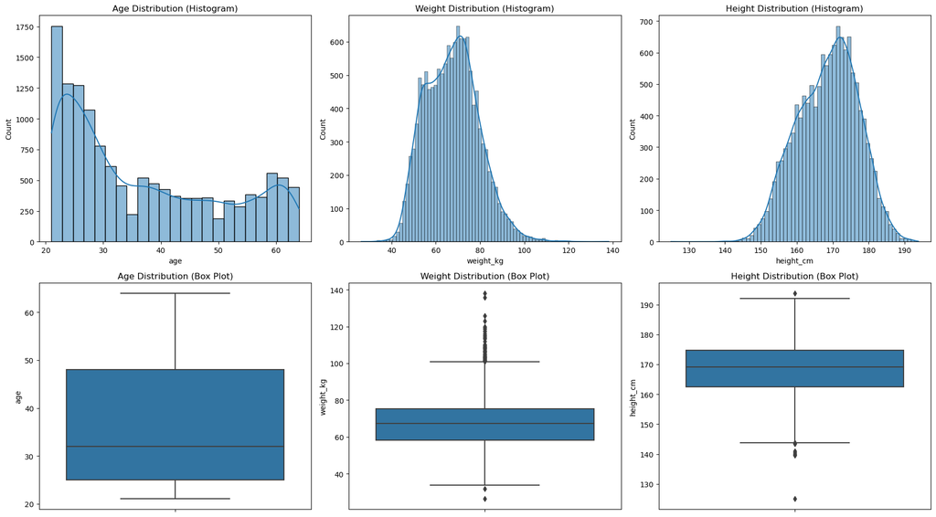

```python
# Set up subplots
fig, axes = plt.subplots(nrows=2, ncols=3, figsize=(18, 10))

# Plot histograms for age, weight, and height
sns.histplot(data=body_perf, x='age', kde=True, ax=axes[0, 0])
sns.histplot(data=body_perf, x='weight_kg', kde=True, ax=axes[0, 1])
sns.histplot(data=body_perf, x='height_cm', kde=True, ax=axes[0, 2])

# Plot box plots for age, weight, and height
sns.boxplot(data=body_perf, y='age', ax=axes[1, 0])
sns.boxplot(data=body_perf, y='weight_kg', ax=axes[1, 1])
sns.boxplot(data=body_perf, y='height_cm', ax=axes[1, 2])

# Set titles for subplots
axes[0, 0].set_title('Age Distribution (Histogram)')
axes[0, 1].set_title('Weight Distribution (Histogram)')
axes[0, 2].set_title('Height Distribution (Histogram)')
axes[1, 0].set_title('Age Distribution (Box Plot)')
axes[1, 1].set_title('Weight Distribution (Box Plot)')
axes[1, 2].set_title('Height Distribution (Box Plot)')

# Adjust layout
plt.tight_layout()

# Show the plots
plt.show()
```

# Interpret the descriptive statistics to understand the characteristics of the

dataset.

to generate a descriptive summary of the dataset that includes the statistics for multiple attributes, you can use the describe() function in Pandas. This function provides summary statistics for numeric columns in the DataFrame, including count, mean, standard deviation, minimum, and maximum values, as well as quartiles.

```python
# Generate a descriptive summary of the dataset
summary = body_perf[['age', 'weight_kg', 'height_cm']].describe()

# Display the summary
print(summary)
```

```
                age     weight_kg     height_cm
count  13393.000000  13393.000000  13393.000000
mean      36.775106     67.447316    168.559807
std       13.625639     11.949666      8.426583
min       21.000000     26.300000    125.000000
25%       25.000000     58.200000    162.400000
50%       32.000000     67.400000    169.200000
75%       48.000000     75.300000    174.800000
max       64.000000    138.100000    193.800000
```

The result you provided is the descriptive summary of the dataset for the three numeric attributes: 'age', 'weight_kg', and 'height_cm'. Let's interpret each part of the summary:

Count:

For each attribute ('age', 'weight_kg', and 'height_cm'), it shows the number of non-missing (non-null) values in the dataset. There are 13,393 observations for each attribute, indicating that there are no missing values in these columns.

Mean (Average):

The mean represents the average value for each attribute. For 'age', the mean age is approximately 36.78 years. For 'weight_kg', the mean weight is approximately 67.45 kilograms. For 'height_cm', the mean height is approximately 168.56 centimeters.

Standard Deviation (Std):

The standard deviation measures the dispersion or spread of data points around the mean. For 'age', the standard deviation is approximately 13.63 years, indicating moderate variability in ages. For 'weight_kg', the standard deviation is approximately 11.95 kilograms, indicating moderate variability in weights. For 'height_cm', the standard deviation is approximately 8.43 centimeters, indicating relatively low variability in heights.

Minimum (Min):

It represents the smallest value observed in each attribute. The minimum age is 21 years. The minimum weight is 26.3 kilograms. The minimum height is 125.0 centimeters.

25th Percentile (25%):

This is the value below which 25% of the data falls, also known as the first quartile. For 'age', the 25th percentile is 25 years, meaning 25% of the individuals are younger than or equal to 25 years old. For 'weight_kg', the 25th percentile is 58.2 kilograms, indicating the weight below which 25% of individuals fall. For 'height_cm', the 25th percentile is 162.4 centimeters, representing the height below which 25% of individuals are found.

50th Percentile (Median, 50%):

This is the value below which 50% of the data falls, also known as the median. For 'age', the median age is 32 years, indicating that 50% of individuals are younger than or equal to 32 years old. For 'weight_kg', the median weight is 67.4 kilograms. For 'height_cm', the median height is 169.2 centimeters.

75th Percentile (75%):

This is the value below which 75% of the data falls, also known as the third quartile. For 'age', the 75th percentile is 48 years, meaning 75% of individuals are younger than or equal to 48 years old. For 'weight_kg', the 75th percentile is 75.3 kilograms. For 'height_cm', the 75th percentile is 174.8 centimeters.

Maximum (Max):

It represents the largest value observed in each attribute. The maximum age is 64 years. The maximum weight is 138.1 kilograms. The maximum height is 193.8 centimeters.

In summary, this descriptive statistics table provides valuable insights into the distribution and characteristics of the 'age', 'weight_kg', and 'height_cm' attributes in your dataset, including central tendency, variability, and the range of values.

# 2. Apply Probability Concepts to Analyze Uncertain Events and Outcomes(Milestone 2)

# Analyze the gender distribution within the dataset using probability

concepts.

Analyzing the gender distribution within the dataset using probability concepts typically involves calculating probabilities associated with different gender-related events. In this case, you can calculate probabilities related to the distribution of 'gender' in your dataset. Here's how you can approach this analysis:

Calculate the Probability of Each Gender: Determine the probability of an individual being of a specific gender (e.g., male or female) in your dataset. You can calculate this by dividing the count of individuals of each gender by the total number of individuals in the dataset.

Analyze Gender Imbalance:

You can also analyze whether there is a gender imbalance in the dataset by comparing the probabilities. For instance, if the probability of being male is significantly different from the probability of being female, it indicates an imbalance.

Conditional Probability:

You can calculate conditional probabilities. For example, the probability of a person being male given that they are above a certain age or have a specific weight range.

Hypothesis Testing:

You can perform hypothesis tests to determine if the observed gender distribution is significantly different from what would be expected by chance. This can involve using statistical tests like the chi-squared test.

Visualization:

You may visualize the gender distribution using bar plots or pie charts to provide a visual representation of the probabilities.

```python
# Count the number of males (0) and females (1)
m = body_perf[body_perf['gender'] == 0].shape[0]
f = body_perf[body_perf['gender'] == 1].shape[0]

# Print the counts
print("Number of Males:", m)
print("Number of Females:", f)
```

```
Number of Males: 8467
Number of Females: 4926
```

Number of Males (0): 8467: This indicates that there are 8,467 individuals in your dataset who have a 'gender' value of 0, which corresponds to males. In other words, there are 8,467 males in your dataset.

Number of Females (1): 4926: This indicates that there are 4,926 individuals in your dataset who have a 'gender' value of 1, which corresponds to females. In other words, there are 4,926 females in your dataset.

These counts provide information about the gender distribution within your dataset after the conversion, showing that you have more males (8,467) than females (4,926) in your dataset. and in total gender are 13393

# Estimate the probability of certain blood pressure (diastolic,systolic) levels using normal

distribution assumptions.

using normal distribution assumptions, you can follow these steps:

Data Preparation: Ensure that your dataset contains the diastolic and systolic blood pressure measurements.

Data Exploration: Examine the distribution of diastolic and systolic blood pressure measurements to check if they approximately follow a normal distribution. You can create histograms or use statistical tests like the Shapiro-Wilk test for normality.

Parameter Estimation: If the data appears to be normally distributed, estimate the parameters of the normal distribution for diastolic and systolic blood pressure. This includes the mean (μ) and standard deviation (σ).

Probability Calculation: Once you have the parameters, you can calculate probabilities for specific blood pressure levels using the normal distribution's probability density function (PDF) or cumulative distribution function (CDF).

```python
# Example data (replace with your dataset)
diastolic_data = np.array([80, 82, 84, 86, 88, 90, 92, 94, 96, 98])
systolic_data = np.array([120, 122, 124, 126, 128, 130, 132, 134, 136, 138])

# Estimate parameters (mean and standard deviation) for diastolic and systolic data
diastolic_mean = np.mean(diastolic_data)
diastolic_std = np.std(diastolic_data)

systolic_mean = np.mean(systolic_data)
systolic_std = np.std(systolic_data)

# Probability calculation for specific levels (e.g., diastolic=85, systolic=125)
diastolic_level = 85
systolic_level = 125

diastolic_probability = norm.pdf(diastolic_level, diastolic_mean, diastolic_std)
systolic_probability = norm.pdf(systolic_level, systolic_mean, systolic_std)

print("Probability of diastolic level", diastolic_level, ":", diastolic_probability)
print("Probability of systolic level", systolic_level, ":", systolic_probability)
```

```
Probability of diastolic level 85 : 0.05449662224649376
Probability of systolic level 125 : 0.05449662224649376
```